# Proyecto Final

BD-165 · Modelos Estadísticos Avanzados de Análisis de Datos

14 de agosto de 2026

[figure not shown]

Colegio Universitario de Cartago

Proyecto Final

BD-165 · Modelos Estadísticos Avanzados de Análisis de Datos

Diplomado en Big Data · Escuela de Ciencias de la Computación  
Prof. David Martínez Salazar

Integrantes del grupo

| Integrante |
| --- |
| Desmond Bermudez Rodriguez |
| Nubia Elena Brenes Valerín |
| Pablo Marin Castillo |
| Wedell Orozco González |
| Kendall Solano Solís |

Desplácese para ver el contenido ↓

# Introducción general

El presente proyecto aplica un conjunto de técnicas estadísticas avanzadas —modelos de regresión, análisis multivariados, métodos de agrupamiento y modelos de series de tiempo— sobre tres conjuntos de datos públicos que documentan fenómenos de comportamiento humano en contextos distintos: la movilidad urbana, el desempeño académico mediado por el uso de inteligencia artificial generativa, y el bienestar laboral frente a la sobrecarga digital. Los tres conjuntos se seleccionaron porque, pese a pertenecer a dominios diferentes, comparten una misma estructura de problema: variables cuantitativas y categóricas que describen el comportamiento o estado de un individuo (usuario, estudiante o colaborador) en un momento o intervalo de tiempo, sobre las cuales interesa identificar relaciones explicativas, perfiles homogéneos de comportamiento y, cuando la naturaleza de los datos lo permite, patrones temporales.

El objetivo general del proyecto es aplicar de forma justificada al menos tres técnicas estadísticas por conjunto de datos —seleccionadas según la pregunta de análisis y la naturaleza de las variables disponibles—, interpretando cada salida en función del problema real que representa y discutiendo el alcance y las limitaciones de los hallazgos obtenidos.

El primer conjunto, **SeoulBikeData**, reúne 8,760 registros horarios sobre la demanda de un sistema de bicicletas compartidas en Seúl junto con variables climáticas; sobre él se aplican regresión lineal múltiple, agrupamiento K-medias y suavización exponencial Holt-Winters para explicar, segmentar y pronosticar la demanda. El segundo, **ai_student_impact_dataset**, describe hábitos de estudio, uso de IA generativa y desempeño de estudiantes; se analiza mediante análisis factorial exploratorio y confirmatorio y agrupamiento k-prototypes, dada la mezcla de variables numéricas y categóricas. El tercero, **mental_health_burnout_prediction_dataset**, contiene 50,000 observaciones sobre carga laboral, exposición a pantallas y síntomas de agotamiento; se aborda con MANOVA, regresión lineal múltiple y K-medias para determinar el efecto conjunto de las variables sobre el perfil sintomático y segmentar niveles de riesgo.

# Sistema de bicicletas compartidas

## Introducción y pregunta de análisis

Seúl opera un sistema de bicicletas compartidas y registró, durante un año completo (diciembre 2017 – noviembre 2018), la cantidad de bicicletas rentadas cada hora junto con las condiciones climáticas de ese momento. Para la operación del sistema es clave anticipar la demanda con el fin de redistribuir la flota entre estaciones y evitar tanto faltantes como sobreoferta de bicicletas.

**Pregunta de análisis:** ¿qué variables climáticas explican mejor la demanda horaria de bicicletas compartidas en Seúl, es posible identificar perfiles de días con demanda similar según el clima, y qué tan bien se puede pronosticar la demanda diaria a corto plazo a partir de su comportamiento histórico?

## Descripción de la base de datos

**Fuente:** Sathishkumar V E, Jangwoo Park y Yongyun Cho (2020). *Seoul Bike Sharing Demand* [Dataset]. UCI Machine Learning Repository. https://doi.org/10.24432/C5F62R — también disponible en Kaggle como `saurabhshahane/seoul-bike-sharing-demand-prediction`.

Cita de los autores originales (Mendeley Data): V E, Sathishkumar (2020), “Seoul Bike Sharing Demand Prediction”, Mendeley Data, V2, doi: 10.17632/zbdtzxcxvg.2

**Licencia / acceso:** CC BY 4.0 — de acceso público y libre, con cita obligatoria a los autores.

El conjunto contiene **8,760 observaciones** (una por cada hora de 365 días) y **14 variables**:

| Variable original | Variable en este documento | Significado | Tipo |
| --- | --- | --- | --- |
| Date | Fecha | Fecha del registro | Fecha |
| Rented Bike Count | Bicis_Rentadas | Bicicletas rentadas en esa hora — **variable objetivo** | Numérica |
| Hour | Hora | Hora del día (0-23) | Numérica |
| Temperature(°C) | Temperatura | Temperatura | Numérica |
| Humidity(%) | Humedad | Humedad relativa | Numérica |
| Wind speed (m/s) | Velocidad_Viento | Velocidad del viento | Numérica |
| Visibility (10m) | Visibilidad | Visibilidad | Numérica |
| Dew point temperature(°C) | Punto_Rocio | Punto de rocío | Numérica |
| Solar Radiation (MJ/m2) | Radiacion_Solar | Radiación solar | Numérica |
| Rainfall(mm) | Lluvia | Lluvia acumulada | Numérica |
| Snowfall (cm) | Nieve | Nieve acumulada | Numérica |
| Seasons | Estacion | Estación del año | Categórica |
| Holiday | Feriado | Feriado / No feriado | Categórica |
| Functioning Day | Dia_Funcional | Si el sistema operaba esa hora (Yes/No) | Categórica |

## Extracción y preparación de los datos

```r
# El archivo original trae el símbolo de grados (°) en los encabezados y
# viene en codificación Latin-1/Windows-1252, no en UTF-8. Si se lee con
# read.csv() normal, R puede truncar el nombre de columna en el símbolo °
# o marcar error — por eso se indica fileEncoding = "latin1".
datos_bici <- read.csv("Data/SeoulBikeData.csv",
                        fileEncoding = "latin1",
                        stringsAsFactors = FALSE)

# Los nombres originales traen espacios, unidades y paréntesis
# (ej. "Temperature(°C)"), lo que obliga a usar backticks todo el tiempo.
# Se renombran a nombres cortos, en el MISMO ORDEN en que vienen en el csv:
colnames(datos_bici) <- c("Fecha", "Bicis_Rentadas", "Hora", "Temperatura",
                           "Humedad", "Velocidad_Viento", "Visibilidad",
                           "Punto_Rocio", "Radiacion_Solar", "Lluvia",
                           "Nieve", "Estacion", "Feriado", "Dia_Funcional")

dim(datos_bici)
```

```
## [1] 8760   14
```

```r
str(datos_bici)
```

```
## 'data.frame':    8760 obs. of  14 variables:
##  $ Fecha           : chr  "01/12/2017" "01/12/2017" "01/12/2017" "01/12/2017" ...
##  $ Bicis_Rentadas  : int  254 204 173 107 78 100 181 460 930 490 ...
##  $ Hora            : int  0 1 2 3 4 5 6 7 8 9 ...
##  $ Temperatura     : num  -5.2 -5.5 -6 -6.2 -6 -6.4 -6.6 -7.4 -7.6 -6.5 ...
##  $ Humedad         : int  37 38 39 40 36 37 35 38 37 27 ...
##  $ Velocidad_Viento: num  2.2 0.8 1 0.9 2.3 1.5 1.3 0.9 1.1 0.5 ...
##  $ Visibilidad     : int  2000 2000 2000 2000 2000 2000 2000 2000 2000 1928 ...
##  $ Punto_Rocio     : num  -17.6 -17.6 -17.7 -17.6 -18.6 -18.7 -19.5 -19.3 -19.8 -22.4 ...
##  $ Radiacion_Solar : num  0 0 0 0 0 0 0 0 0.01 0.23 ...
##  $ Lluvia          : num  0 0 0 0 0 0 0 0 0 0 ...
##  $ Nieve           : num  0 0 0 0 0 0 0 0 0 0 ...
##  $ Estacion        : chr  "Winter" "Winter" "Winter" "Winter" ...
##  $ Feriado         : chr  "No Holiday" "No Holiday" "No Holiday" "No Holiday" ...
##  $ Dia_Funcional   : chr  "Yes" "Yes" "Yes" "Yes" ...
```

```r
summary(datos_bici)
```

```
##     Fecha           Bicis_Rentadas        Hora        Temperatura
##  Length:8760        Min.   :   0.0   Min.   : 0.00   Min.   :-17.80
##  Class :character   1st Qu.: 191.0   1st Qu.: 5.75   1st Qu.:  3.50
##  Mode  :character   Median : 504.5   Median :11.50   Median : 13.70
##                     Mean   : 704.6   Mean   :11.50   Mean   : 12.88
##                     3rd Qu.:1065.2   3rd Qu.:17.25   3rd Qu.: 22.50
##                     Max.   :3556.0   Max.   :23.00   Max.   : 39.40
##     Humedad      Velocidad_Viento  Visibilidad    Punto_Rocio
##  Min.   : 0.00   Min.   :0.000    Min.   :  27   Min.   :-30.600
##  1st Qu.:42.00   1st Qu.:0.900    1st Qu.: 940   1st Qu.: -4.700
##  Median :57.00   Median :1.500    Median :1698   Median :  5.100
##  Mean   :58.23   Mean   :1.725    Mean   :1437   Mean   :  4.074
##  3rd Qu.:74.00   3rd Qu.:2.300    3rd Qu.:2000   3rd Qu.: 14.800
##  Max.   :98.00   Max.   :7.400    Max.   :2000   Max.   : 27.200
##  Radiacion_Solar      Lluvia            Nieve           Estacion
##  Min.   :0.0000   Min.   : 0.0000   Min.   :0.00000   Length:8760
##  1st Qu.:0.0000   1st Qu.: 0.0000   1st Qu.:0.00000   Class :character
##  Median :0.0100   Median : 0.0000   Median :0.00000   Mode  :character
##  Mean   :0.5691   Mean   : 0.1487   Mean   :0.07507
##  3rd Qu.:0.9300   3rd Qu.: 0.0000   3rd Qu.:0.00000
##  Max.   :3.5200   Max.   :35.0000   Max.   :8.80000
##    Feriado          Dia_Funcional
##  Length:8760        Length:8760
##  Class :character   Class :character
##  Mode  :character   Mode  :character
##
##
##
```

```r
# Valores faltantes y duplicados
colSums(is.na(datos_bici))
```

```
##            Fecha   Bicis_Rentadas             Hora      Temperatura
##                0                0                0                0
##          Humedad Velocidad_Viento      Visibilidad      Punto_Rocio
##                0                0                0                0
##  Radiacion_Solar           Lluvia            Nieve         Estacion
##                0                0                0                0
##          Feriado    Dia_Funcional
##                0                0
```

```r
sum(duplicated(datos_bici))
```

```
## [1] 0
```

```r
# Tipos de dato
datos_bici$Fecha <- lubridate::dmy(datos_bici$Fecha)  # formato original: dd/mm/aaaa
datos_bici$Estacion      <- as.factor(datos_bici$Estacion)
datos_bici$Feriado       <- as.factor(datos_bici$Feriado)
datos_bici$Dia_Funcional <- as.factor(datos_bici$Dia_Funcional)

table(datos_bici$Dia_Funcional)
```

```
##
##   No  Yes
##  295 8465
```

```r
# Se descartan las horas en que el sistema estaba cerrado: en esas horas
# Bicis_Rentadas es 0 por definición (el servicio no operaba), no porque
# el clima haya sido malo. Dejarlas adentro sesgaría la regresión y el
# clustering con ceros que no representan demanda real.
datos_bici_func <- subset(datos_bici, Dia_Funcional == "Yes")
nrow(datos_bici_func)
```

```
## [1] 8465
```

Interpretación: el conjunto tiene 8,760 observaciones y 14 variables, sin valores faltantes ni filas duplicadas. `Estacion`, `Feriado` y `Dia_Funcional` se convirtieron a factor por ser categóricas. Se excluyeron las horas con `Dia_Funcional == "No"` (sistema cerrado) para que la variable objetivo refleje demanda real; el escalado (`scale()`) de las variables climáticas se hace más adelante, específicamente para la Técnica 2 (K-medias), que sí lo requiere.

## Exploración de los datos (EDA)

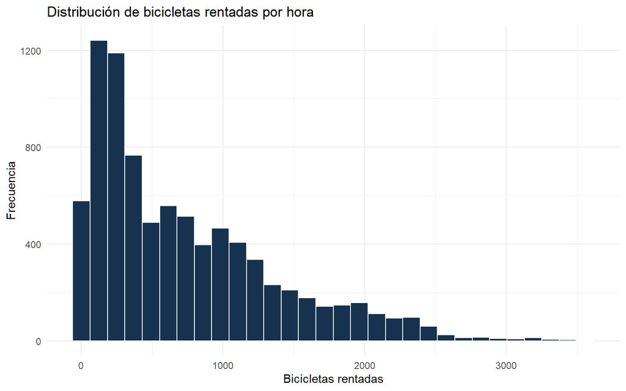

```r
# Distribución de la variable objetivo
ggplot(datos_bici_func, aes(x = Bicis_Rentadas)) +
  geom_histogram(bins = 30, fill = col_navy, color = "white") +
  labs(title = "Distribución de bicicletas rentadas por hora",
       x = "Bicicletas rentadas", y = "Frecuencia") +
  theme_minimal()
```

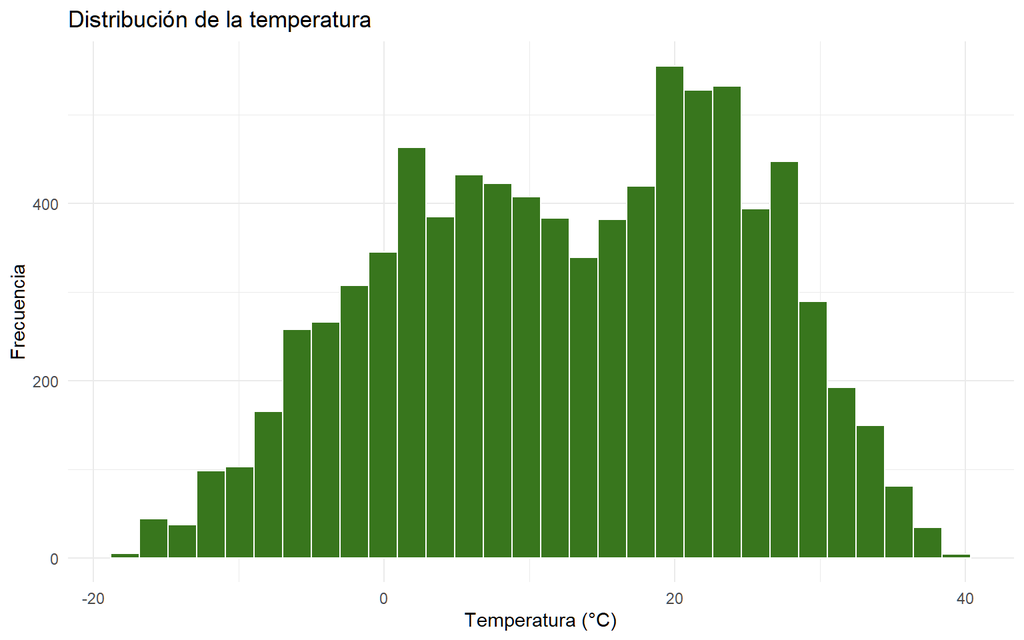

```r
# Distribución de la temperatura
ggplot(datos_bici_func, aes(x = Temperatura)) +
  geom_histogram(bins = 30, fill = col_teal, color = "white") +
  labs(title = "Distribución de la temperatura", x = "Temperatura (°C)",
       y = "Frecuencia") +
  theme_minimal()
```

```r
# Matriz de correlaciones entre variables numéricas
num_vars_bici <- datos_bici_func %>%
  select(Bicis_Rentadas, Temperatura, Humedad, Velocidad_Viento,
         Visibilidad, Punto_Rocio, Radiacion_Solar, Lluvia, Nieve)

round(cor(num_vars_bici), 3)
```

```
##                  Bicis_Rentadas Temperatura Humedad Velocidad_Viento
## Bicis_Rentadas            1.000       0.563  -0.202            0.125
## Temperatura               0.563       1.000   0.166           -0.038
## Humedad                  -0.202       0.166   1.000           -0.337
## Velocidad_Viento          0.125      -0.038  -0.337            1.000
## Visibilidad               0.212       0.028  -0.549            0.180
## Punto_Rocio               0.400       0.914   0.539           -0.177
## Radiacion_Solar           0.274       0.355  -0.457            0.326
## Lluvia                   -0.129       0.052   0.237           -0.025
## Nieve                    -0.152      -0.218   0.110           -0.004
##                  Visibilidad Punto_Rocio Radiacion_Solar Lluvia  Nieve
## Bicis_Rentadas         0.212       0.400           0.274 -0.129 -0.152
## Temperatura            0.028       0.914           0.355  0.052 -0.218
## Humedad               -0.549       0.539          -0.457  0.237  0.110
## Velocidad_Viento       0.180      -0.177           0.326 -0.025 -0.004
## Visibilidad            1.000      -0.183           0.153 -0.170 -0.123
## Punto_Rocio           -0.183       1.000           0.099  0.127 -0.150
## Radiacion_Solar        0.153       0.099           1.000 -0.074 -0.073
## Lluvia                -0.170       0.127          -0.074  1.000  0.009
## Nieve                 -0.123      -0.150          -0.073  0.009  1.000
```

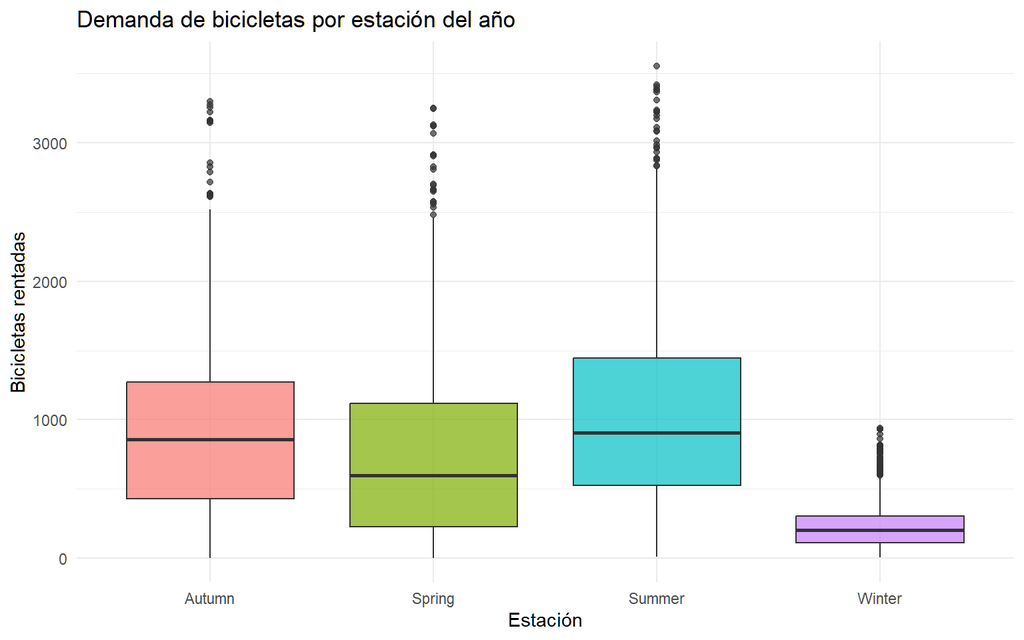

```r
# Demanda por estación del año y por hora del día
ggplot(datos_bici_func, aes(x = Estacion, y = Bicis_Rentadas, fill = Estacion)) +
  geom_boxplot(alpha = 0.7) +
  labs(title = "Demanda de bicicletas por estación del año",
       x = "Estación", y = "Bicicletas rentadas") +
  theme_minimal() +
  theme(legend.position = "none")
```

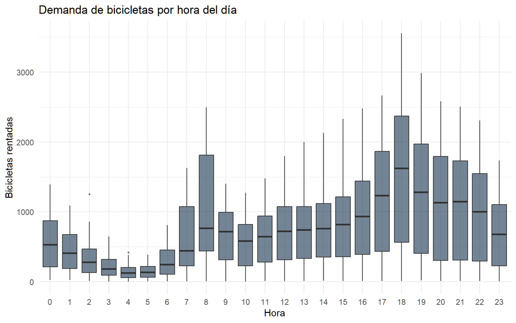

```r
ggplot(datos_bici_func, aes(x = factor(Hora), y = Bicis_Rentadas)) +
  geom_boxplot(fill = col_navy, alpha = 0.6, outlier.size = 0.5) +
  labs(title = "Demanda de bicicletas por hora del día",
       x = "Hora", y = "Bicicletas rentadas") +
  theme_minimal()
```

Interpretación: `Bicis_Rentadas` muestra una distribución sesgada a la derecha (muchas horas de demanda baja y pocas horas pico), mientras que `Temperatura` se ve más simétrica por cubrir un año completo con las cuatro estaciones. En la matriz de correlaciones, `Temperatura` y `Punto_Rocio` salen muy correlacionadas entre sí (ambas miden condiciones térmicas parecidas) — señal de multicolinealidad que se trata en la Técnica 1. `Bicis_Rentadas` correlaciona positivo con `Temperatura` y negativo con `Humedad`, `Lluvia` y `Nieve`: a mejor clima, más demanda. El boxplot por estación muestra mayor demanda en los meses cálidos y menor en invierno, y el boxplot por hora deja ver los picos típicos de un patrón de transporte (entrada y salida laboral) más que puramente recreativo.

## Modelos aplicados

### Técnica 1 — Regresión Lineal Múltiple

La pregunta de análisis requiere **cuantificar** cómo cada variable climática (temperatura, humedad, viento, lluvia, etc.) afecta la cantidad de bicicletas rentadas por hora — una variable dependiente numérica continua. La Regresión Lineal Múltiple permite estimar el efecto individual de cada predictor manteniendo los demás constantes e identificar cuáles son estadísticamente significativos, igual que se hizo en el Laboratorio 3 del curso con las ventas de la cadena minorista.

```r
modelo_bici_completo <- lm(Bicis_Rentadas ~ Temperatura + Humedad +
                              Velocidad_Viento + Visibilidad + Punto_Rocio +
                              Radiacion_Solar + Lluvia + Nieve,
                            data = datos_bici_func)
summary(modelo_bici_completo)
```

```
##
## Call:
## lm(formula = Bicis_Rentadas ~ Temperatura + Humedad + Velocidad_Viento +
##     Visibilidad + Punto_Rocio + Radiacion_Solar + Lluvia + Nieve,
##     data = datos_bici_func)
##
## Residuals:
##      Min       1Q   Median       3Q      Max
## -1388.74  -295.57   -57.15   207.87  2330.68
##
## Coefficients:
##                    Estimate Std. Error t value Pr(>|t|)
## (Intercept)       8.723e+02  1.035e+02   8.428  < 2e-16 ***
## Temperatura       3.603e+01  4.058e+00   8.879  < 2e-16 ***
## Humedad          -1.083e+01  1.153e+00  -9.394  < 2e-16 ***
## Velocidad_Viento  5.368e+01  5.571e+00   9.636  < 2e-16 ***
## Visibilidad       2.305e-03  1.081e-02   0.213  0.83121
## Punto_Rocio       6.182e-01  4.284e+00   0.144  0.88526
## Radiacion_Solar  -1.182e+02  8.517e+00 -13.879  < 2e-16 ***
## Lluvia           -5.330e+01  4.861e+00 -10.965  < 2e-16 ***
## Nieve             3.739e+01  1.239e+01   3.017  0.00256 **
## ---
## Signif. codes:  0 '***' 0.001 '**' 0.01 '*' 0.05 '.' 0.1 ' ' 1
##
## Residual standard error: 484.1 on 8456 degrees of freedom
## Multiple R-squared:  0.4325, Adjusted R-squared:  0.432
## F-statistic: 805.7 on 8 and 8456 DF,  p-value: < 2.2e-16
```

```r
car::vif(modelo_bici_completo)
```

```
##      Temperatura          Humedad Velocidad_Viento      Visibilidad
##        87.152504        20.132908         1.198871         1.565867
##      Punto_Rocio  Radiacion_Solar           Lluvia            Nieve
##       116.219367         1.975087         1.080975         1.093974
```

```r
# Temperatura y Punto_Rocio se comportan como variables redundantes entre
# sí (igual que gasto_publicidad/trafico_web en el Laboratorio 3): se
# conserva Temperatura, por ser la variable climática de referencia y más
# fácil de interpretar, y se descarta Punto_Rocio.
modelo_bici_final <- lm(Bicis_Rentadas ~ Temperatura + Humedad +
                           Velocidad_Viento + Visibilidad +
                           Radiacion_Solar + Lluvia + Nieve,
                         data = datos_bici_func)
summary(modelo_bici_final)
```

```
##
## Call:
## lm(formula = Bicis_Rentadas ~ Temperatura + Humedad + Velocidad_Viento +
##     Visibilidad + Radiacion_Solar + Lluvia + Nieve, data = datos_bici_func)
##
## Residuals:
##     Min      1Q  Median      3Q     Max
## -1379.5  -295.3   -57.6   208.0  2331.2
##
## Coefficients:
##                    Estimate Std. Error t value Pr(>|t|)
## (Intercept)       858.32530   36.09679  23.778  < 2e-16 ***
## Temperatura        36.61388    0.54160  67.603  < 2e-16 ***
## Humedad           -10.67098    0.39790 -26.818  < 2e-16 ***
## Velocidad_Viento   53.63554    5.56306   9.641  < 2e-16 ***
## Visibilidad         0.00244    0.01077   0.227  0.82081
## Radiacion_Solar  -118.47947    8.31020 -14.257  < 2e-16 ***
## Lluvia            -53.37989    4.82893 -11.054  < 2e-16 ***
## Nieve              37.26738   12.36382   3.014  0.00258 **
## ---
## Signif. codes:  0 '***' 0.001 '**' 0.01 '*' 0.05 '.' 0.1 ' ' 1
##
## Residual standard error: 484.1 on 8457 degrees of freedom
## Multiple R-squared:  0.4325, Adjusted R-squared:  0.4321
## F-statistic: 920.9 on 7 and 8457 DF,  p-value: < 2.2e-16
```

```r
car::vif(modelo_bici_final)
```

```
##      Temperatura          Humedad Velocidad_Viento      Visibilidad
##         1.552337         2.399677         1.195768         1.554150
##  Radiacion_Solar           Lluvia            Nieve
##         1.880399         1.067003         1.088773
```

```r
AIC(modelo_bici_completo, modelo_bici_final)
```

|  | df | AIC |
| --- | --- | --- |
| modelo_bici_completo | 10 | 128700.1 |
| modelo_bici_final | 9 | 128698.1 |

```r
BIC(modelo_bici_completo, modelo_bici_final)
```

|  | df | BIC |
| --- | --- | --- |
| modelo_bici_completo | 10 | 128770.5 |
| modelo_bici_final | 9 | 128761.5 |

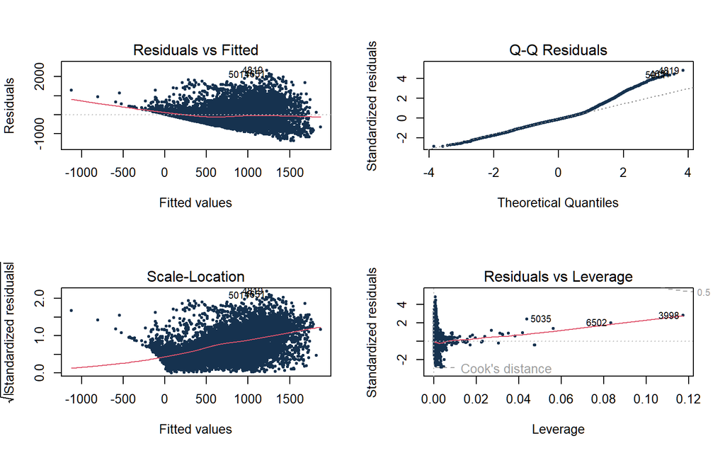

```r
par(mfrow = c(2, 2))
plot(modelo_bici_final, col = col_navy, pch = 19, cex = 0.5)
```

```r
par(mfrow = c(1, 1))

# Ejemplo de predicción: un día templado, soleado y sin lluvia ni nieve
nueva_hora <- data.frame(Temperatura = 20, Humedad = 50,
                          Velocidad_Viento = 2, Visibilidad = 1800,
                          Radiacion_Solar = 1.5, Lluvia = 0, Nieve = 0)
predict(modelo_bici_final, newdata = nueva_hora, interval = "prediction")
```

```
##        fit      lwr      upr
## 1 990.9971 41.94071 1940.053
```

Con un R² ajustado de apenas 0.432, el clima por sí solo explica menos de la mitad de la variación horaria en la demanda — el ejemplo de predicción (20°C, 50% humedad, sin lluvia ni nieve) estimó 991 bicicletas, pero con un intervalo de predicción al 95% muy amplio (42 a 1,940), reflejo de que factores no climáticos (hora del día, día de la semana, feriados) pesan bastante y no están en este modelo.

### Técnica 2 — K-medias

Más allá de cuantificar el efecto de cada variable por separado, interesa identificar **perfiles completos de día** (combinaciones típicas de clima) para apoyar la logística de redistribución de bicicletas. K-medias agrupa observaciones según la similitud conjunta de varias variables numéricas sin necesitar una variable dependiente, igual que se hizo con los jugadores de fútbol y con los usuarios de StreamCR en los laboratorios de conglomerados del curso.

```r
# Se agrega la información a nivel de DÍA (no de hora), porque el interés
# operativo es "qué tipo de día es este", no "qué tipo de hora es esta".
diario_bici <- datos_bici_func %>%
  group_by(Fecha) %>%
  summarise(
    Total_Bicis       = sum(Bicis_Rentadas),
    Temp_prom         = mean(Temperatura),
    Humedad_prom      = mean(Humedad),
    Viento_prom       = mean(Velocidad_Viento),
    Visibilidad_prom  = mean(Visibilidad),
    Radiacion_prom    = mean(Radiacion_Solar),
    Lluvia_total      = sum(Lluvia),
    Nieve_total       = sum(Nieve),
    Estacion          = first(Estacion),
    .groups = "drop"
  ) %>%
  arrange(Fecha)

nrow(diario_bici)  # debería rondar los 350-365 días
```

```
## [1] 353
```

```r
vars_clima <- diario_bici %>%
  select(Temp_prom, Humedad_prom, Viento_prom, Visibilidad_prom,
         Radiacion_prom, Lluvia_total, Nieve_total)

vars_clima_z <- scale(vars_clima)
round(colMeans(vars_clima_z), 2)
```

```
##        Temp_prom     Humedad_prom      Viento_prom Visibilidad_prom
##                0                0                0                0
##   Radiacion_prom     Lluvia_total      Nieve_total
##                0                0                0
```

```r
round(apply(vars_clima_z, 2, sd), 2)
```

```
##        Temp_prom     Humedad_prom      Viento_prom Visibilidad_prom
##                1                1                1                1
##   Radiacion_prom     Lluvia_total      Nieve_total
##                1                1                1
```

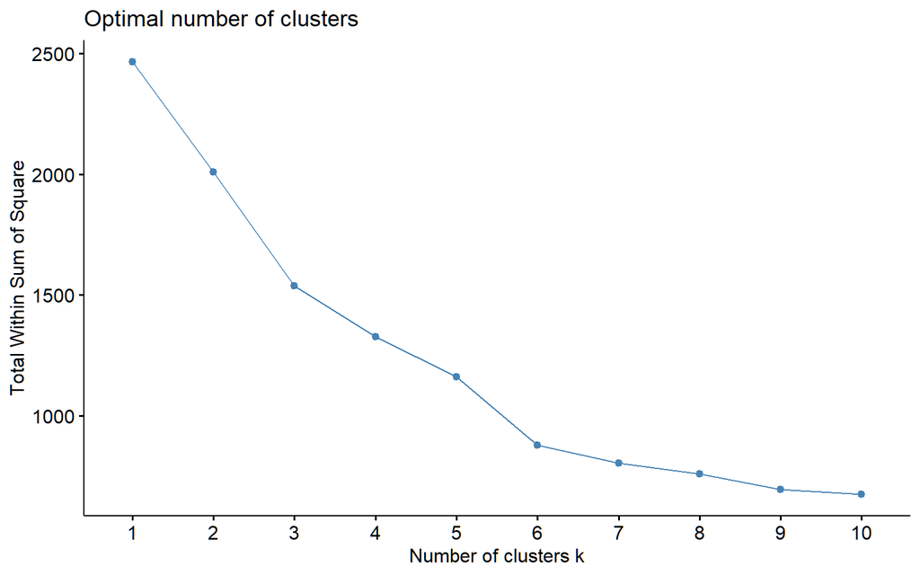

```r
set.seed(123)
fviz_nbclust(vars_clima_z, kmeans, method = "wss")
```

```r
# Ajustar 'centers' al valor de k identificado en el gráfico del codo
set.seed(123)
modelo_km_bici <- kmeans(vars_clima_z, centers = 4, nstart = 25)
modelo_km_bici
```

```
## K-means clustering with 4 clusters of sizes 88, 9, 166, 90
##
## Cluster means:
##     Temp_prom Humedad_prom Viento_prom Visibilidad_prom Radiacion_prom
## 1  0.04621431    1.1014305  -0.4330674       -1.0956208     -0.8731213
## 2 -1.09426793    0.7247338  -0.2786397       -0.9110210     -1.1446485
## 3  0.67744659   -0.1111272  -0.1346360        0.3116441      0.8214395
## 4 -1.18527313   -0.9444596   0.6996362        0.5875655     -0.5469160
##   Lluvia_total  Nieve_total
## 1   0.76280733 -0.170542426
## 2  -0.08937322  5.651635709
## 3  -0.25011411 -0.211585895
## 4  -0.27559716 -0.008152549
##
## Clustering vector:
##   [1] 4 4 1 4 4 1 1 4 4 2 4 4 4 4 1 4 4 2 2 2 2 1 1 1 4 4 4 4 1 1 4 4 4 4 4 4 4
##  [38] 4 4 4 4 4 4 1 1 1 1 1 1 4 1 4 4 4 4 4 4 4 4 4 4 2 4 4 4 4 4 4 4 4 4 4 4 4
##  [75] 4 4 4 4 4 4 4 4 4 4 2 4 4 4 1 1 4 4 4 1 3 3 4 1 1 3 3 3 3 3 1 3 3 1 1 4 4
## [112] 3 3 1 1 1 1 1 1 3 3 1 3 1 3 1 1 4 4 3 4 3 4 1 3 3 3 3 3 3 3 1 1 3 3 3 3 3
## [149] 3 3 1 1 4 3 3 1 3 3 3 3 1 1 1 3 1 1 1 3 3 3 1 3 3 3 3 3 3 3 3 3 3 3 3 3 3
## [186] 3 3 3 3 3 3 3 3 1 3 3 1 3 3 3 3 3 3 3 3 1 1 1 1 1 1 1 3 3 1 3 3 3 1 1 1 1
## [223] 3 3 3 3 3 3 3 3 3 3 3 3 3 3 3 1 3 3 3 3 3 3 3 3 3 3 3 3 3 3 3 3 3 3 3 3 3
## [260] 3 3 3 3 3 1 3 3 1 1 1 1 3 3 3 1 3 3 3 3 3 3 3 3 3 3 3 3 1 3 1 1 3 3 3 3 3
## [297] 3 3 4 3 1 1 3 3 4 4 3 3 3 1 3 3 3 3 3 3 3 1 3 3 1 4 1 4 4 3 3 3 3 1 1 1 1
## [334] 1 3 3 3 1 1 4 4 1 4 1 4 4 2 2 1 1 4 4 4
##
## Within cluster sum of squares by cluster:
## [1] 522.48694  40.28527 387.69020 297.80153
##  (between_SS / total_SS =  49.3 %)
##
## Available components:
##
## [1] "cluster"      "centers"      "totss"        "withinss"     "tot.withinss"
## [6] "betweenss"    "size"         "iter"         "ifault"
```

```r
diario_bici$Grupo <- factor(modelo_km_bici$cluster)
table(diario_bici$Grupo)
```

```
##
##   1   2   3   4
##  88   9 166  90
```

```r
aggregate(cbind(Total_Bicis, Temp_prom, Humedad_prom, Viento_prom,
                 Visibilidad_prom, Radiacion_prom, Lluvia_total,
                 Nieve_total) ~ Grupo, data = diario_bici, FUN = mean)
```

| Grupo | Total_Bicis | Temp_prom | Humedad_prom | Viento_prom | Visibilidad_prom | Radiacion_prom | Lluvia_total | Nieve_total |
| --- | --- | --- | --- | --- | --- | --- | --- | --- |
| 1 | 13108.636 | 13.3174020 | 74.53961 | 1.467485 | 895.8929 | 0.2917162 | 12.5693182 | 0.3613636 |
| 2 | 5336.111 | -0.0472222 | 68.93981 | 1.559722 | 986.5602 | 0.2058796 | 2.5222222 | 51.6222222 |
| 3 | 25427.723 | 20.7144327 | 56.51431 | 1.645733 | 1587.0796 | 0.8274096 | 0.6271084 | 0.0000000 |
| 4 | 8330.300 | -1.1136574 | 44.12639 | 2.144028 | 1722.6000 | 0.3948380 | 0.3266667 | 1.7911111 |

```r
# Validación cruzada contra la estación real (Estacion NO se usó para
# formar los grupos, solo clima), igual que en el laboratorio de fútbol
table(diario_bici$Grupo, diario_bici$Estacion)
```

```
##
##     Autumn Spring Summer Winter
##   1     21     29     20     18
##   2      2      0      0      7
##   3     44     50     72      0
##   4     14     11      0     65
```

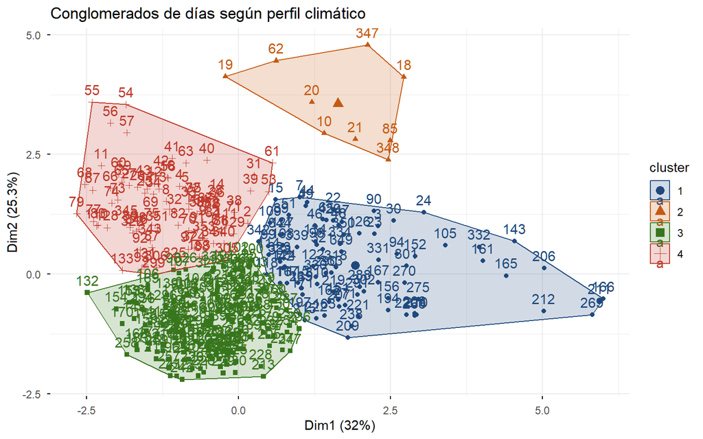

```r
fviz_cluster(modelo_km_bici,
             data = vars_clima_z,
             palette = c("#1F497D", "#C55A11", "#38761D", "#C0392B"),
             ellipse.type = "convex",
             ggtheme = theme_minimal(),
             main = "Conglomerados de días según perfil climático")
```

Perfilando cada grupo por sus medias:

Grupo 3 (166 días) — “días cálidos y soleados de alta demanda”: temperatura promedio 20.7°C, la radiación solar más alta (0.83 MJ/m²) y prácticamente sin lluvia ni nieve. Es el grupo con mayor demanda (25,428 bicicletas/día en promedio) y coincide sobre todo con primavera y verano (72 días de verano, 50 de primavera, 0 de invierno). Grupo 4 (90 días) — “días fríos, secos y ventosos de baja demanda”: la temperatura más baja (-1.1°C), la humedad más baja (44%) y el viento más fuerte. Demanda de 8,330 bicicletas/día. Casi todo invierno (65 de 90 días). Grupo 1 (88 días) — “días templados y lluviosos”: temperatura moderada (13.3°C) pero la mayor lluvia acumulada (12.6 mm) y humedad alta (74.5%). Demanda intermedia (13,109/día), repartido en las cuatro estaciones casi por igual. Grupo 2 (9 días) — “días de nevada intensa”: un grupo pequeño y muy distintivo, con 51.6 cm de nieve acumulada en promedio (muy por encima de cualquier otro grupo) y temperatura cercana a 0°C. Es el grupo de menor demanda (5,336/día) y ocurre casi exclusivamente en invierno (7 de 9 días).

La tabla cruzada contra Estacion confirma que el clima por sí solo “redescubre” un patrón estacional razonable (el Grupo 3 domina en verano/primavera, el Grupo 4 y el Grupo 2 dominan en invierno), aunque con más mezcla entre estaciones que en el caso de las posiciones de fútbol — lógico, porque las fronteras climáticas son continuas, no discretas.

### Técnica 3 — Series de Tiempo (Holt-Winters)

La operación también necesita **pronosticar** cuántas bicicletas se van a rentar en los próximos días para planificar mantenimiento y redistribución, no solo explicar el pasado. La demanda diaria total muestra tendencia (crece hacia el verano) y un patrón que se repite cada semana (más o menos uso entre semana vs. fin de semana), por lo que un modelo de suavización exponencial con componente estacional (Holt-Winters) es apropiado, igual que en el laboratorio de series de tiempo del curso.

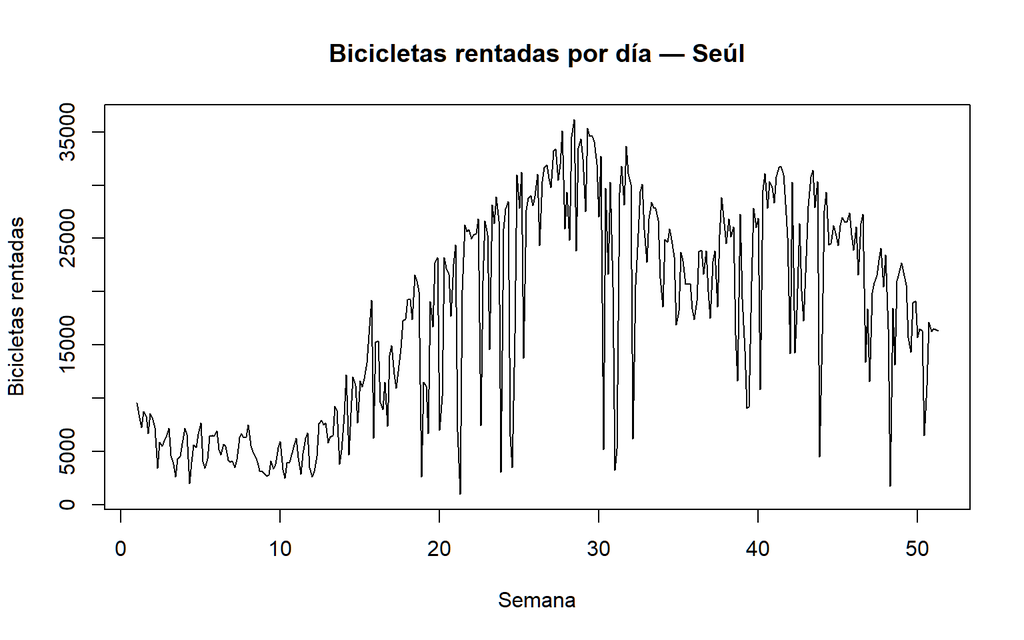

```r
serie_bici <- ts(diario_bici$Total_Bicis, frequency = 7)

plot(serie_bici,
     main = "Bicicletas rentadas por día — Seúl",
     ylab = "Bicicletas rentadas", xlab = "Semana")
```

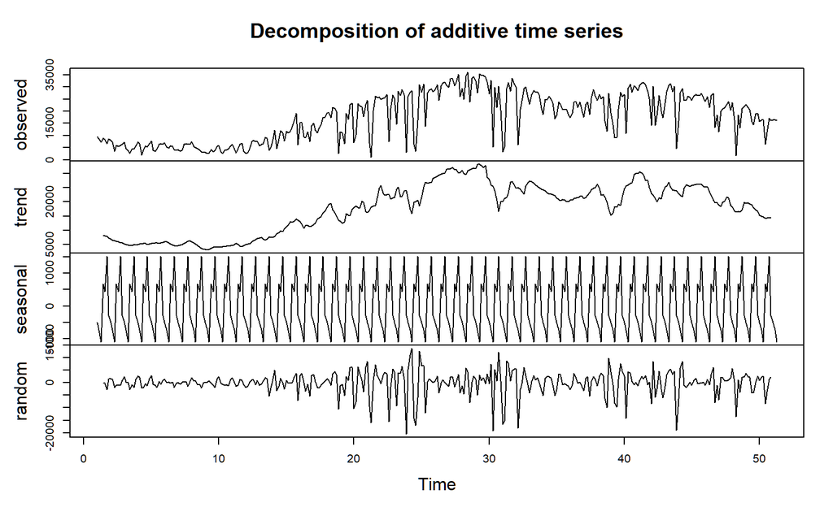

```r
desc_bici <- decompose(serie_bici, type = "additive")
plot(desc_bici)
```

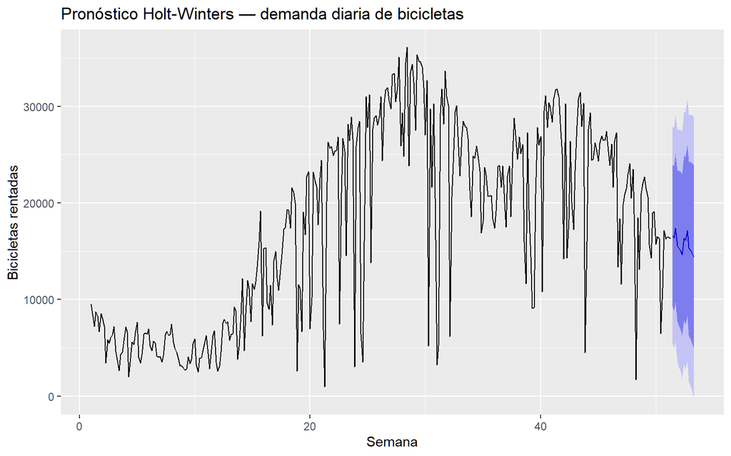

```r
ajuste_ses_bici  <- ses(serie_bici, h = 14)
ajuste_holt_bici <- holt(serie_bici, h = 14)
ajuste_hw_bici   <- hw(serie_bici, seasonal = "additive", h = 14)

autoplot(ajuste_hw_bici) +
  labs(title = "Pronóstico Holt-Winters — demanda diaria de bicicletas",
       x = "Semana", y = "Bicicletas rentadas")
```

```r
cat("Modelo SES\n");          accuracy(ajuste_ses_bici)
```

```
## Modelo SES
```

```
##                    ME   RMSE      MAE       MPE    MAPE     MASE      ACF1
## Training set 111.5971 5666.6 3912.185 -24.80396 44.5789 0.735938 0.2029487
```

```r
cat("Modelo Holt\n");         accuracy(ajuste_holt_bici)
```

```
## Modelo Holt
```

```
##                    ME     RMSE      MAE       MPE     MAPE      MASE      ACF1
## Training set 141.2498 5703.325 3883.789 -21.63566 44.29777 0.7305963 0.2039793
```

```r
cat("Modelo Holt-Winters\n"); accuracy(ajuste_hw_bici)
```

```
## Modelo Holt-Winters
```

```
##                    ME    RMSE      MAE       MPE     MAPE      MASE      ACF1
## Training set 199.1628 5619.31 3838.699 -21.02414 42.79802 0.7221143 0.1931969
```

Comparando las métricas de error sobre el conjunto de entrenamiento:

| Modelo | RMSE | MAE | MAPE |
| --- | --- | --- | --- |
| SES | 5666.6 | 3912.2 | 44.58% |
| Holt | 5703.3 | 3883.8 | 44.30% |
| Holt-Winters | 5619.3 | 3838.7 | 42.80% |

Holt-Winters obtuvo el menor error en las tres métricas, confirmando que la estacionalidad semanal sí aporta algo de poder predictivo. Sin embargo, la mejora es mucho más modesta que la observada en el laboratorio de ventas (ahí Holt-Winters bajaba el MAPE de ~3% a ~1.1%; aquí solo baja de ~44.6% a ~42.8%). Un MAPE cercano al 43% indica que la demanda diaria de bicicletas tiene mucha variabilidad día a día que ni la tendencia ni el patrón semanal logran capturar — coherente con el R² modesto obtenido en la regresión, que ya había mostrado que el clima (y por extensión el calendario) no explica toda la historia.

## Resultados

Las tres técnicas cuentan una historia consistente: el clima influye claramente en la demanda de bicicletas en Seúl (temperatura y lluvia como los factores más fuertes), pero está lejos de explicarla por completo. La regresión deja sin explicar cerca del 57% de la varianza horaria; el K-medias logra separar los días en cuatro perfiles climáticos razonables pero con una calidad de agrupamiento moderada (49.3%); y el pronóstico de Holt-Winters, aunque el mejor de los tres modelos de suavización, arrastra un error relativamente alto (MAPE ≈ 43%). En conjunto, esto sugiere que factores no climáticos —hora del día, día de la semana, feriados, eventos puntuales— tienen un peso considerable en la demanda, algo que ya se insinuaba en el boxplot por hora del EDA.

## Discusión

El hallazgo más relevante es que el clima, aunque significativo, no es suficiente por sí solo: un R² ajustado de 0.432 deja claro que un modelo de producción necesitaría incorporar variables de calendario (hora, día de la semana, feriado) para mejorar sustancialmente la predicción. Dos coeficientes de la regresión resultaron contraintuitivos (Radiacion_Solar negativa y Nieve positiva), lo que probablemente refleja que el modelo lineal aditivo no captura bien la interacción entre radiación solar y hora del día, ni tiene suficientes observaciones con nieve para estimar ese efecto con confianza — una limitación de asumir relaciones puramente lineales. El agrupamiento de K-medias, con un 49.3% de varianza explicada entre grupos, es notablemente más débil que el 90% obtenido en el laboratorio de fútbol, coherente con la naturaleza continua (no categórica) del clima. Finalmente, el pronóstico de Holt-Winters, con un MAPE de ~43%, es mucho menos preciso que el de ventas mensuales del laboratorio del curso, lo que indica que la demanda diaria de bicicletas está sujeta a más ruido día a día (eventos puntuales, cambios abruptos de clima) que un modelo de tendencia + estacionalidad semanal no puede anticipar. Por último, los datos corresponden a una sola ciudad y un solo año (dic. 2017 – nov. 2018), por lo que estas conclusiones no necesariamente se generalizan a otras ciudades o a años con clima atípico.

# Estudiantes en el uso de la IA

## Introducción y pregunta de análisis

Este informe estudia cómo las características académicas, los hábitos de estudio y el uso de inteligencia artificial generativa se relacionan con el rendimiento, la retención de habilidades y el agotamiento estudiantil. El análisis combina exploración descriptiva, análisis factorial y k-prototypes para resumir relaciones entre variables numéricas y categóricas e identificar perfiles retrospectivos de estudiantes. Debido al carácter observacional de los datos, los resultados describen asociaciones y no demuestran relaciones causales.

## Descripción de la base de datos

### Fuente de datos

- Archivo analizado: `Data/ai_student_impact_dataset.csv`.
- URL de la fuente: `https://www.kaggle.com/datasets/laveshjadon/ai-impact-on-students`.
- La fuente de Kaggle identifica el conjunto de datos como `Impact of Ai on Students`.
- El archivo CSV contiene informacion sobre estudiantes, uso de IA generativa, rendimiento academico, ansiedad, retencion de habilidades y riesgo de agotamiento.
- Kaggle describe el conjunto de datos como un recurso para analizar como el uso de herramientas de IA generativa se relaciona con el rendimiento academico, el desarrollo de habilidades, la salud mental y el riesgo de *burnout* en estudiantes.

### Contenido del conjunto de datos

El conjunto de datos contiene observaciones a nivel de estudiante sobre el posible impacto del uso de herramientas de IA generativa durante un semestre academico. Cada fila representa a un estudiante identificado por `Student_ID`.

El archivo permite analizar relaciones entre:

- Caracteristicas academicas del estudiante: area de estudio, año academico y GPA antes del semestre.
- Uso de IA generativa: horas semanales, caso de uso principal, nivel de habilidad en *prompting*, diversidad de herramientas y suscripcion pagada.
- Habitos y percepciones: horas de estudio tradicional, dependencia percibida de la IA, politica institucional y ansiedad durante los examenes.
- Resultados posteriores: GPA al final del semestre, retencion de habilidades y nivel de riesgo de *burnout*.

### Estructura general

- Numero de registros: 50 000.
- Numero de variables en el archivo original: 16, incluida `Student_ID`.
- Numero de variables analiticas en `df`: 15, ya que `Student_ID` se utiliza como nombre de fila al cargar los datos.
- Valores faltantes detectados: 0.
- Unidad de observacion: estudiante.
- Periodo implicito: un semestre academico, inferido a partir de `Pre_Semester_GPA` y `Post_Semester_GPA`.
- Variables objetivo sugeridas por la fuente: `Post_Semester_GPA`, `Skill_Retention_Score` y `Burnout_Risk_Level`.

### Diccionario de variables

[output not shown]

### Observaciones de documentación

`Student_ID` es una llave de identificacion y no debe utilizarse como variable explicativa con significado academico. Las variables con escalas de 1 a 10 (`Perceived_AI_Dependency` y `Anxiety_Level_During_Exams`) usan el menor valor como nivel bajo o mínimo y el mayor como nivel alto o severo. La fuente describe `Skill_Retention_Score` como un puntaje de 0 a 100; en el CSV, el mínimo observado es 10.78 y el máximo es 100. En Kaggle, la política institucional aparece como `Strictly_Ban`; en el CSV local, el valor observado es `Strict_Ban`.

## Extracción y preparación de los datos

### Carga y preparación de los datos

Esta etapa carga la fuente, revisa su estructura, ajusta los tipos de las variables y construye los subconjuntos que se utilizaran en los analisis posteriores.

El archivo se carga usando `Student_ID` como nombre de fila, por lo que dicha variable no se conserva como columna analitica en `df`.

```r
data_path <- file.path("Data", "ai_student_impact_dataset.csv")

data_path
```

```
## [1] "Data/ai_student_impact_dataset.csv"
```

```r
df <- read.csv(data_path, header = TRUE, row.names = 1)
```

### Revisión preliminar

```r
head(df, 10)
```

|  | Major_Category | Year_of_Study | Pre_Semester_GPA | Weekly_GenAI_Hours | Primary_Use_Case | Prompt_Engineering_Skill | Tool_Diversity | Paid_Subscription | Traditional_Study_Hours | Perceived_AI_Dependency | Institutional_Policy | Anxiety_Level_During_Exams | Post_Semester_GPA | Skill_Retention_Score | Burnout_Risk_Level |
| --- | --- | --- | --- | --- | --- | --- | --- | --- | --- | --- | --- | --- | --- | --- | --- |
| 100001 | Humanities | Senior | 2.418 | 23.31 | Copywriting/Drafting | Beginner | 1 | True | 8.13 | 5 | Allowed_With_Citation | 6 | 2.393 | 86.44 | High |
| 100002 | Medical | Junior | 3.821 | 1.12 | Ideation | Advanced | 5 | False | 16.65 | 3 | Allowed_With_Citation | 9 | 3.696 | 69.39 | Low |
| 100003 | Business | Freshman | 3.398 | 21.26 | Summarizing_Reading | Beginner | 2 | False | 10.35 | 5 | Strict_Ban | 9 | 3.499 | 73.93 | Medium |
| 100004 | Business | Senior | 3.789 | 1.82 | Copywriting/Drafting | Intermediate | 4 | False | 15.23 | 2 | Allowed_With_Citation | 2 | 4.000 | 63.58 | Medium |
| 100005 | STEM | Sophomore | 3.635 | 9.29 | Debugging/Troubleshooting | Advanced | 4 | False | 12.55 | 4 | Allowed_With_Citation | 4 | 3.798 | 100.00 | Medium |
| 100006 | STEM | Junior | 3.449 | 6.50 | Debugging/Troubleshooting | Beginner | 1 | False | 14.19 | 4 | Allowed_With_Citation | 5 | 3.666 | 65.92 | High |
| 100007 | STEM | Freshman | 3.622 | 31.41 | Summarizing_Reading | Advanced | 5 | True | 13.11 | 8 | Allowed_With_Citation | 7 | 4.000 | 67.97 | Medium |
| 100008 | Arts | Junior | 2.746 | 5.33 | Copywriting/Drafting | Intermediate | 3 | False | 18.45 | 2 | Actively_Encouraged | 1 | 2.965 | 85.09 | Medium |
| 100009 | Business | Sophomore | 3.420 | 2.00 | Debugging/Troubleshooting | Beginner | 2 | True | 2.87 | 1 | Strict_Ban | 5 | 3.396 | 55.71 | Medium |
| 100010 | Business | Sophomore | 3.046 | 19.99 | Debugging/Troubleshooting | Intermediate | 2 | True | 12.49 | 3 | Strict_Ban | 8 | 2.978 | 87.18 | High |

```r
tail(df, 10)
```

|  | Major_Category | Year_of_Study | Pre_Semester_GPA | Weekly_GenAI_Hours | Primary_Use_Case | Prompt_Engineering_Skill | Tool_Diversity | Paid_Subscription | Traditional_Study_Hours | Perceived_AI_Dependency | Institutional_Policy | Anxiety_Level_During_Exams | Post_Semester_GPA | Skill_Retention_Score | Burnout_Risk_Level |
| --- | --- | --- | --- | --- | --- | --- | --- | --- | --- | --- | --- | --- | --- | --- | --- |
| 149991 | Business | Senior | 2.970 | 2.63 | Summarizing_Reading | Intermediate | 2 | False | 24.95 | 1 | Allowed_With_Citation | 1 | 3.238 | 84.87 | Medium |
| 149992 | Humanities | Freshman | 2.708 | 13.34 | Copywriting/Drafting | Intermediate | 2 | False | 11.65 | 4 | Allowed_With_Citation | 5 | 2.785 | 65.24 | High |
| 149993 | Business | Graduate | 2.829 | 2.59 | Debugging/Troubleshooting | Advanced | 3 | True | 7.54 | 1 | Allowed_With_Citation | 4 | 3.176 | 84.04 | Low |
| 149994 | STEM | Sophomore | 3.588 | 25.64 | Debugging/Troubleshooting | Intermediate | 3 | True | 4.62 | 5 | Strict_Ban | 10 | 3.841 | 58.44 | High |
| 149995 | Humanities | Senior | 3.556 | 15.19 | Summarizing_Reading | Advanced | 4 | True | 1.00 | 3 | Actively_Encouraged | 5 | 3.788 | 74.76 | High |
| 149996 | Business | Senior | 2.899 | 12.16 | Copywriting/Drafting | Beginner | 2 | False | 13.36 | 2 | Allowed_With_Citation | 2 | 3.584 | 66.16 | High |
| 149997 | STEM | Senior | 2.870 | 2.51 | Copywriting/Drafting | Intermediate | 1 | False | 4.67 | 3 | Actively_Encouraged | 3 | 3.096 | 81.62 | Medium |
| 149998 | Business | Senior | 3.177 | 15.87 | Summarizing_Reading | Advanced | 5 | True | 3.92 | 4 | Allowed_With_Citation | 5 | 3.605 | 97.21 | High |
| 149999 | Business | Junior | 3.398 | 19.91 | Debugging/Troubleshooting | Intermediate | 5 | False | 7.10 | 5 | Allowed_With_Citation | 3 | 3.527 | 84.12 | Medium |
| 150000 | Arts | Sophomore | 3.242 | 3.30 | Copywriting/Drafting | Beginner | 1 | False | 3.93 | 2 | Allowed_With_Citation | 6 | 3.261 | 76.16 | Low |

```r
dim(df)
```

```
## [1] 50000    15
```

```r
str(df)
```

```
## 'data.frame':    50000 obs. of  15 variables:
##  $ Major_Category            : chr  "Humanities" "Medical" "Business" "Business" ...
##  $ Year_of_Study             : chr  "Senior" "Junior" "Freshman" "Senior" ...
##  $ Pre_Semester_GPA          : num  2.42 3.82 3.4 3.79 3.63 ...
##  $ Weekly_GenAI_Hours        : num  23.31 1.12 21.26 1.82 9.29 ...
##  $ Primary_Use_Case          : chr  "Copywriting/Drafting" "Ideation" "Summarizing_Reading" "Copywriting/Drafting" ...
##  $ Prompt_Engineering_Skill  : chr  "Beginner" "Advanced" "Beginner" "Intermediate" ...
##  $ Tool_Diversity            : int  1 5 2 4 4 1 5 3 2 2 ...
##  $ Paid_Subscription         : chr  "True" "False" "False" "False" ...
##  $ Traditional_Study_Hours   : num  8.13 16.65 10.35 15.23 12.55 ...
##  $ Perceived_AI_Dependency   : int  5 3 5 2 4 4 8 2 1 3 ...
##  $ Institutional_Policy      : chr  "Allowed_With_Citation" "Allowed_With_Citation" "Strict_Ban" "Allowed_With_Citation" ...
##  $ Anxiety_Level_During_Exams: int  6 9 9 2 4 5 7 1 5 8 ...
##  $ Post_Semester_GPA         : num  2.39 3.7 3.5 4 3.8 ...
##  $ Skill_Retention_Score     : num  86.4 69.4 73.9 63.6 100 ...
##  $ Burnout_Risk_Level        : chr  "High" "Low" "Medium" "Medium" ...
```

```r
sum(is.na(df))
```

```
## [1] 0
```

```r
summary(df)
```

```
##  Major_Category     Year_of_Study      Pre_Semester_GPA Weekly_GenAI_Hours
##  Length:50000       Length:50000       Min.   :1.183    Min.   : 0.000
##  Class :character   Class :character   1st Qu.:2.834    1st Qu.: 2.390
##  Mode  :character   Mode  :character   Median :3.210    Median : 5.800
##                                        Mean   :3.146    Mean   : 8.428
##                                        3rd Qu.:3.521    3rd Qu.:11.720
##                                        Max.   :3.998    Max.   :40.000
##  Primary_Use_Case   Prompt_Engineering_Skill Tool_Diversity Paid_Subscription
##  Length:50000       Length:50000             Min.   :1.0    Length:50000
##  Class :character   Class :character         1st Qu.:2.0    Class :character
##  Mode  :character   Mode  :character         Median :3.0    Mode  :character
##                                              Mean   :2.8
##                                              3rd Qu.:4.0
##                                              Max.   :5.0
##  Traditional_Study_Hours Perceived_AI_Dependency Institutional_Policy
##  Min.   : 1.00           Min.   : 1.000          Length:50000
##  1st Qu.: 7.56           1st Qu.: 2.000          Class :character
##  Median :11.18           Median : 3.000          Mode  :character
##  Mean   :11.21           Mean   : 3.505
##  3rd Qu.:14.71           3rd Qu.: 5.000
##  Max.   :35.86           Max.   :10.000
##  Anxiety_Level_During_Exams Post_Semester_GPA Skill_Retention_Score
##  Min.   : 1.000             Min.   :1.000     Min.   : 10.78
##  1st Qu.: 3.000             1st Qu.:3.024     1st Qu.: 66.82
##  Median : 4.000             Median :3.421     Median : 76.00
##  Mean   : 4.271             Mean   :3.349     Mean   : 75.80
##  3rd Qu.: 6.000             3rd Qu.:3.749     3rd Qu.: 85.19
##  Max.   :10.000             Max.   :4.000     Max.   :100.00
##  Burnout_Risk_Level
##  Length:50000
##  Class :character
##  Mode  :character
##
##
##
```

```r
colnames(df)
```

```
##  [1] "Major_Category"             "Year_of_Study"
##  [3] "Pre_Semester_GPA"           "Weekly_GenAI_Hours"
##  [5] "Primary_Use_Case"           "Prompt_Engineering_Skill"
##  [7] "Tool_Diversity"             "Paid_Subscription"
##  [9] "Traditional_Study_Hours"    "Perceived_AI_Dependency"
## [11] "Institutional_Policy"       "Anxiety_Level_During_Exams"
## [13] "Post_Semester_GPA"          "Skill_Retention_Score"
## [15] "Burnout_Risk_Level"
```

```r
categoricas_originales <- c(
  "Primary_Use_Case",
  "Major_Category",
  "Year_of_Study",
  "Prompt_Engineering_Skill",
  "Institutional_Policy",
  "Burnout_Risk_Level",
  "Paid_Subscription"
)

lapply(df[categoricas_originales], unique)
```

```
## $Primary_Use_Case
## [1] "Copywriting/Drafting"      "Ideation"
## [3] "Summarizing_Reading"       "Debugging/Troubleshooting"
## [5] "Direct_Answer_Generation"
##
## $Major_Category
## [1] "Humanities" "Medical"    "Business"   "STEM"       "Arts"
##
## $Year_of_Study
## [1] "Senior"    "Junior"    "Freshman"  "Sophomore" "Graduate"
##
## $Prompt_Engineering_Skill
## [1] "Beginner"     "Advanced"     "Intermediate"
##
## $Institutional_Policy
## [1] "Allowed_With_Citation" "Strict_Ban"            "Actively_Encouraged"
##
## $Burnout_Risk_Level
## [1] "High"   "Low"    "Medium"
##
## $Paid_Subscription
## [1] "True"  "False"
```

La revisión inicial muestra que el objeto `df` contiene 15 variables analíticas para 50 000 estudiantes: 8 variables numéricas y 7 variables categóricas. De las variables categóricas, 6 se tratan como factores y `Paid_Subscription` como una variable booleana, en concordancia con la descripcion de la fuente.

### Conversión de tipos

```r
df$Burnout_Risk_Level <- factor(df$Burnout_Risk_Level, levels = c("Low", "Medium", "High"))
df$Institutional_Policy <- factor(
  df$Institutional_Policy,
  levels = c("Strict_Ban", "Allowed_With_Citation", "Actively_Encouraged")
)
df$Prompt_Engineering_Skill <- factor(
  df$Prompt_Engineering_Skill,
  levels = c("Beginner", "Intermediate", "Advanced")
)
df$Primary_Use_Case <- factor(df$Primary_Use_Case)
df$Major_Category <- factor(df$Major_Category)
df$Year_of_Study <- factor(
  df$Year_of_Study,
  levels = c("Freshman", "Sophomore", "Junior", "Senior", "Graduate")
)
df$Paid_Subscription <- case_when(
  df$Paid_Subscription %in% c(TRUE, "TRUE", "True", "true", 1, "1") ~ TRUE,
  df$Paid_Subscription %in% c(FALSE, "FALSE", "False", "false", 0, "0") ~ FALSE,
  TRUE ~ NA
)

str(df)
```

```
## 'data.frame':    50000 obs. of  15 variables:
##  $ Major_Category            : Factor w/ 5 levels "Arts","Business",..: 3 4 2 2 5 5 5 1 2 2 ...
##  $ Year_of_Study             : Factor w/ 5 levels "Freshman","Sophomore",..: 4 3 1 4 2 3 1 3 2 2 ...
##  $ Pre_Semester_GPA          : num  2.42 3.82 3.4 3.79 3.63 ...
##  $ Weekly_GenAI_Hours        : num  23.31 1.12 21.26 1.82 9.29 ...
##  $ Primary_Use_Case          : Factor w/ 5 levels "Copywriting/Drafting",..: 1 4 5 1 2 2 5 1 2 2 ...
##  $ Prompt_Engineering_Skill  : Factor w/ 3 levels "Beginner","Intermediate",..: 1 3 1 2 3 1 3 2 1 2 ...
##  $ Tool_Diversity            : int  1 5 2 4 4 1 5 3 2 2 ...
##  $ Paid_Subscription         : logi  TRUE FALSE FALSE FALSE FALSE FALSE ...
##  $ Traditional_Study_Hours   : num  8.13 16.65 10.35 15.23 12.55 ...
##  $ Perceived_AI_Dependency   : int  5 3 5 2 4 4 8 2 1 3 ...
##  $ Institutional_Policy      : Factor w/ 3 levels "Strict_Ban","Allowed_With_Citation",..: 2 2 1 2 2 2 2 3 1 1 ...
##  $ Anxiety_Level_During_Exams: int  6 9 9 2 4 5 7 1 5 8 ...
##  $ Post_Semester_GPA         : num  2.39 3.7 3.5 4 3.8 ...
##  $ Skill_Retention_Score     : num  86.4 69.4 73.9 63.6 100 ...
##  $ Burnout_Risk_Level        : Factor w/ 3 levels "Low","Medium",..: 3 1 2 2 2 3 2 2 2 3 ...
```

Después de la conversión, `df` contiene 6 columnas de tipo factor, de las cuales 4 representan variables cualitativas ordinales; 1 variable booleana y 8 variables numéricas. Estas últimas se clasifican en 5 variables cuantitativas continuas y 3 variables cuantitativas discretas.

### Construcción de matrices analíticas

```r
matriz_num <- df %>% select(where(is.double))
matriz_num2 <- df %>% select(where(is.integer))
matriz_cat <- df %>% select(where(is.factor), where(is.logical))
matriz_numeric_all <- df %>% select(where(is.numeric))
```

## Exploración de los datos (EDA)

El analisis exploratorio se organiza en una revision univariada de cada variable y una revision bivariada de las relaciones entre pares de variables.

### Variables cuantitativas continuas

```r
str(matriz_num)
```

‘data.frame’: 50000 obs. of 5 variables: $ Pre_Semester_GPA : num 2.42 3.82 3.4 3.79 3.63 … $ Weekly_GenAI_Hours : num 23.31 1.12 21.26 1.82 9.29 … $ Traditional_Study_Hours: num 8.13 16.65 10.35 15.23 12.55 … $ Post_Semester_GPA : num 2.39 3.7 3.5 4 3.8 … $ Skill_Retention_Score : num 86.4 69.4 73.9 63.6 100 …

```r
summary(matriz_num)
```

Pre_Semester_GPA Weekly_GenAI_Hours Traditional_Study_Hours Post_Semester_GPA Min. :1.183 Min. : 0.000 Min. : 1.00 Min. :1.000  
1st Qu.:2.834 1st Qu.: 2.390 1st Qu.: 7.56 1st Qu.:3.024  
Median :3.210 Median : 5.800 Median :11.18 Median :3.421  
Mean :3.146 Mean : 8.428 Mean :11.21 Mean :3.349  
3rd Qu.:3.521 3rd Qu.:11.720 3rd Qu.:14.71 3rd Qu.:3.749  
Max. :3.998 Max. :40.000 Max. :35.86 Max. :4.000  
Skill_Retention_Score Min. : 10.78  
1st Qu.: 66.82  
Median : 76.00  
Mean : 75.80  
3rd Qu.: 85.19  
Max. :100.00

```r
kable_ajustada(res_est(matriz_num))
```

| Estadistico | Post_Semester_GPA | Pre_Semester_GPA | Skill_Retention_Score | Traditional_Study_Hours | Weekly_GenAI_Hours |
| --- | --- | --- | --- | --- | --- |
| Min | 1.000 | 1.183 | 10.780 | 1.000 | 0.000 |
| Q1 | 3.024 | 2.834 | 66.820 | 7.560 | 2.390 |
| Media | 3.349 | 3.146 | 75.798 | 11.209 | 8.428 |
| Mediana | 3.421 | 3.210 | 76.000 | 11.180 | 5.800 |
| Q3 | 3.749 | 3.521 | 85.190 | 14.710 | 11.720 |
| Max | 4.000 | 3.998 | 100.000 | 35.860 | 40.000 |
| Moda | 3.985 | 3.397 | 75.702 | 11.392 | 1.310 |
| SD | 0.496 | 0.479 | 13.282 | 5.156 | 8.269 |
| Var | 0.246 | 0.229 | 176.402 | 26.589 | 68.384 |
| IQR | 0.725 | 0.687 | 18.370 | 7.150 | 9.330 |

Para cada variable numerica continua se evalua la distribucion con histograma, boxplot, curva normal teorica, medidas de tendencia central y prueba de normalidad de Lilliefors. Las hipotesis son:

- $H_0$: la distribucion de la variable es compatible con una distribucion normal.
- $H_1$: la distribucion de la variable presenta una diferencia estadisticamente significativa respecto de una distribucion normal.

Dado que la muestra contiene 50 000 observaciones, los p-valores pueden detectar desviaciones pequenas; por eso, se interpretan junto con el estadistico $D$ y la evidencia visual.

[interactive chart not shown]

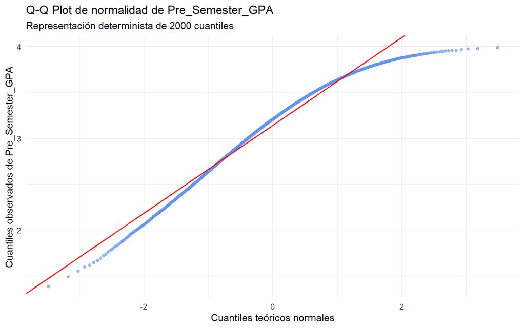

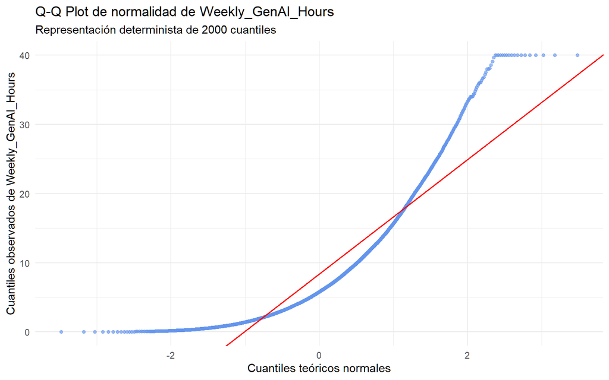

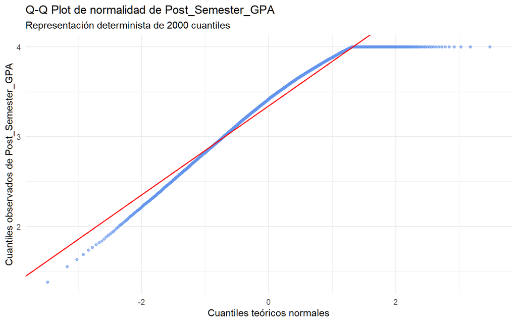

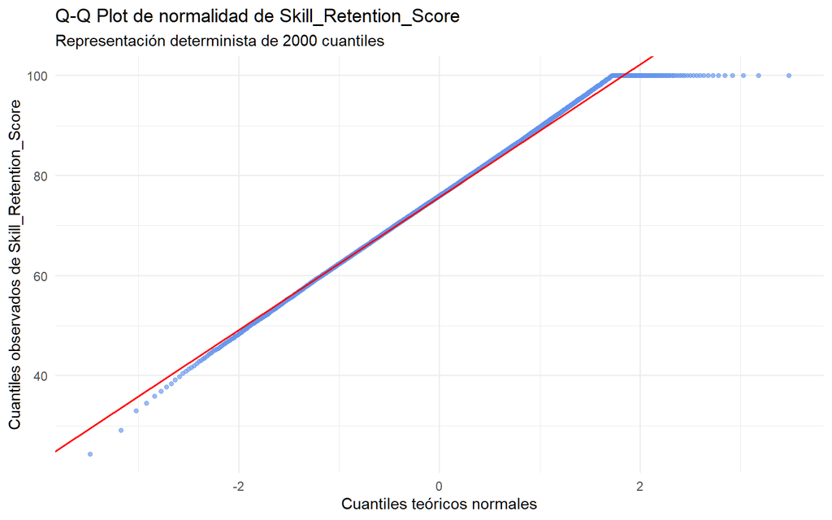

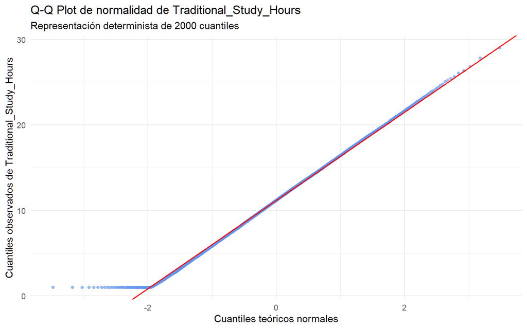

Las pruebas de Lilliefors muestran una diferencia estadisticamente significativa respecto de una normal perfecta en 5 de las 5 variables analizadas. Los valores de $D$ indican que la maxima diferencia entre la distribucion acumulada observada y la normal esperada se encuentra entre 2.4 % y 15.4 %. Con 50 000 observaciones, esta conclusion debe complementarse con los histogramas, boxplots y Q-Q plots.

Las variables presentan distintos grados de discrepancia frente a una normal perfecta. En particular, `Weekly_GenAI_Hours` es asimétrica: su media es 8.43 horas, superior a la mediana de 5.8, y el 50 % central se encuentra entre 2.39 y 11.72 horas. Esto sugiere que una fracción de estudiantes con uso elevado desplaza el promedio hacia arriba; no implica que ese uso sea beneficioso o perjudicial.

El GPA promedio pasa de 3.146 antes del semestre a 3.349 después, una diferencia descriptiva de 0.203 puntos. El desplazamiento es observable en la muestra, pero sin un diseño causal no puede atribuirse al uso de IA ni separarse de otros cambios ocurridos durante el semestre.

El 67.2 % de los estudiantes presenta un puntaje de retención de habilidades superior a 70 puntos. La mediana de horas semanales de estudio tradicional es 11.18 horas. En conjunto, los gráficos describen patrones de uso y rendimiento, pero no prueban que la cantidad o el tipo de uso de IA produzca mejoras academicas.

### Variables cuantitativas discretas

```r
str(matriz_num2)
```

‘data.frame’: 50000 obs. of 3 variables: $ Tool_Diversity : int 1 5 2 4 4 1 5 3 2 2 … $ Perceived_AI_Dependency : int 5 3 5 2 4 4 8 2 1 3 … $ Anxiety_Level_During_Exams: int 6 9 9 2 4 5 7 1 5 8 …

```r
kable_ajustada(res_est(matriz_num2))
```

| Estadistico | Anxiety_Level_During_Exams | Perceived_AI_Dependency | Tool_Diversity |
| --- | --- | --- | --- |
| Min | 1.000 | 1.000 | 1.000 |
| Q1 | 3.000 | 2.000 | 2.000 |
| Media | 4.271 | 3.505 | 2.800 |
| Mediana | 4.000 | 3.000 | 3.000 |
| Q3 | 6.000 | 5.000 | 4.000 |
| Max | 10.000 | 10.000 | 5.000 |
| Moda | 3.994 | 2.992 | 2.995 |
| SD | 2.144 | 1.821 | 1.188 |
| Var | 4.597 | 3.315 | 1.411 |
| IQR | 3.000 | 3.000 | 2.000 |

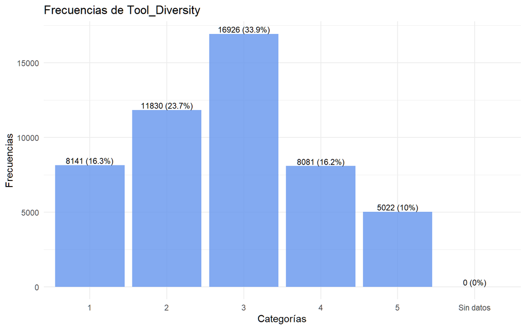

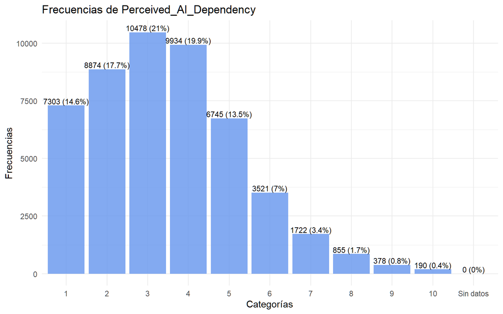

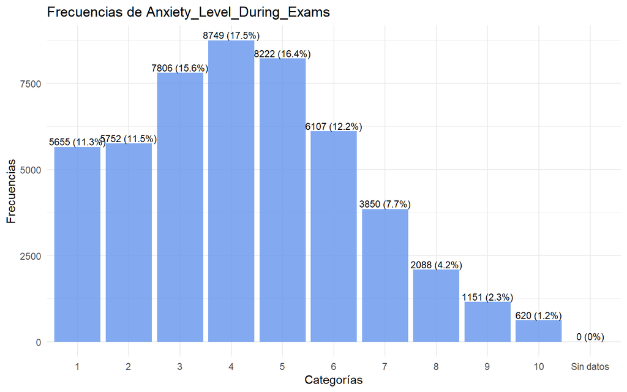

### Variables cualitativas

```r
str(matriz_cat)
```

```
## 'data.frame':    50000 obs. of  7 variables:
##  $ Major_Category          : Factor w/ 5 levels "Arts","Business",..: 3 4 2 2 5 5 5 1 2 2 ...
##  $ Year_of_Study           : Factor w/ 5 levels "Freshman","Sophomore",..: 4 3 1 4 2 3 1 3 2 2 ...
##  $ Primary_Use_Case        : Factor w/ 5 levels "Copywriting/Drafting",..: 1 4 5 1 2 2 5 1 2 2 ...
##  $ Prompt_Engineering_Skill: Factor w/ 3 levels "Beginner","Intermediate",..: 1 3 1 2 3 1 3 2 1 2 ...
##  $ Institutional_Policy    : Factor w/ 3 levels "Strict_Ban","Allowed_With_Citation",..: 2 2 1 2 2 2 2 3 1 1 ...
##  $ Burnout_Risk_Level      : Factor w/ 3 levels "Low","Medium",..: 3 1 2 2 2 3 2 2 2 3 ...
##  $ Paid_Subscription       : logi  TRUE FALSE FALSE FALSE FALSE FALSE ...
```

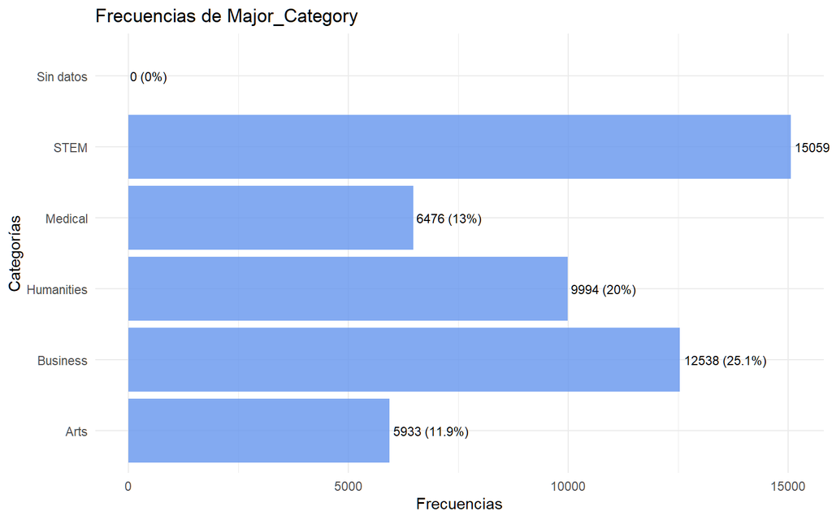

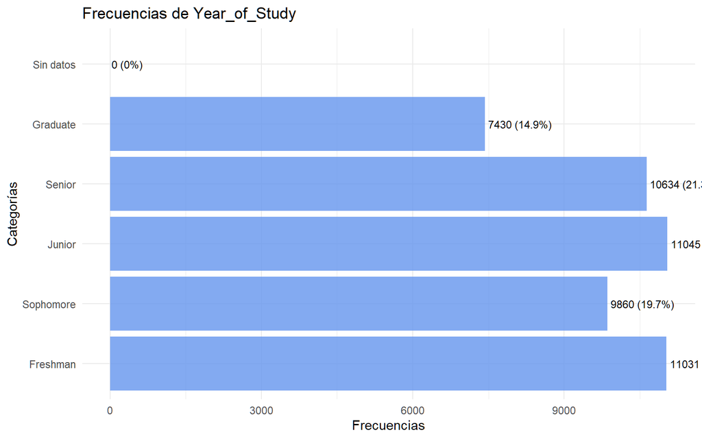

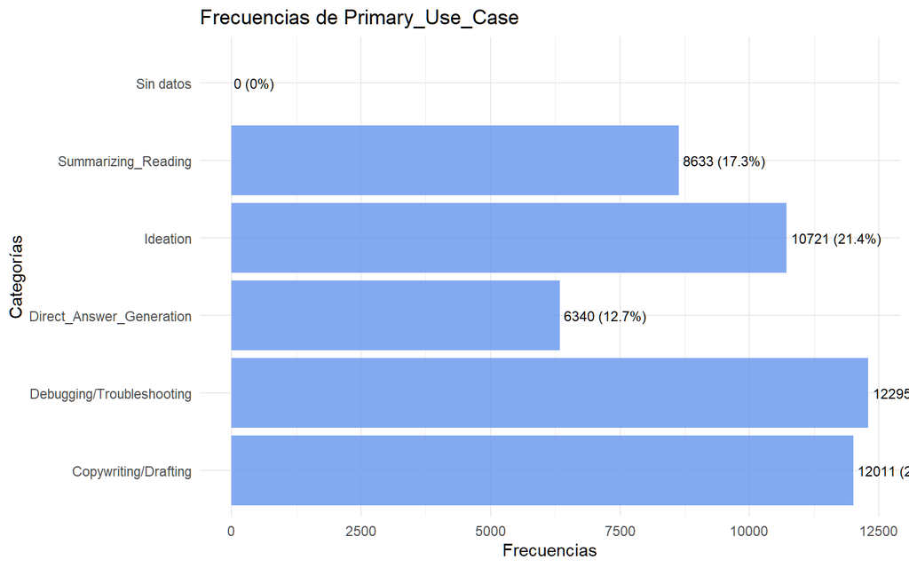

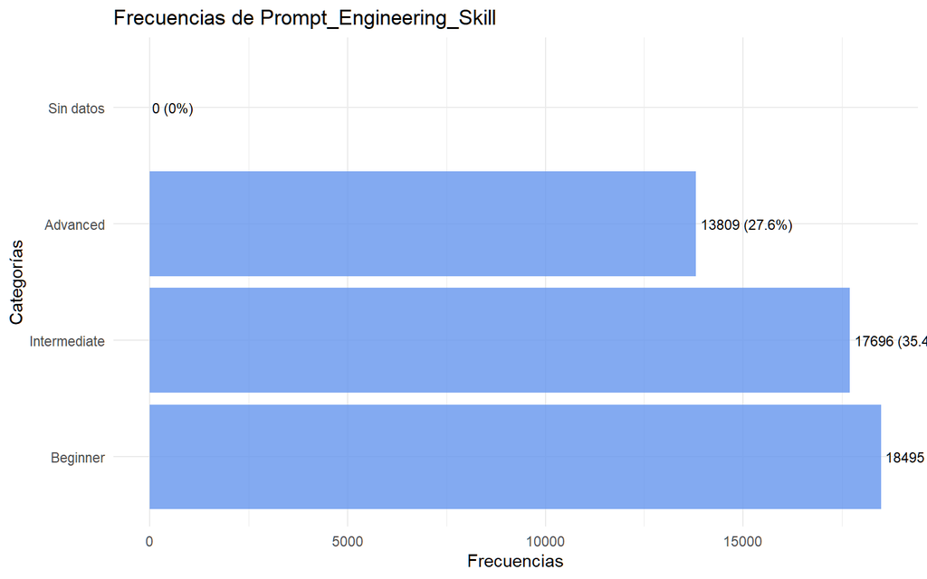

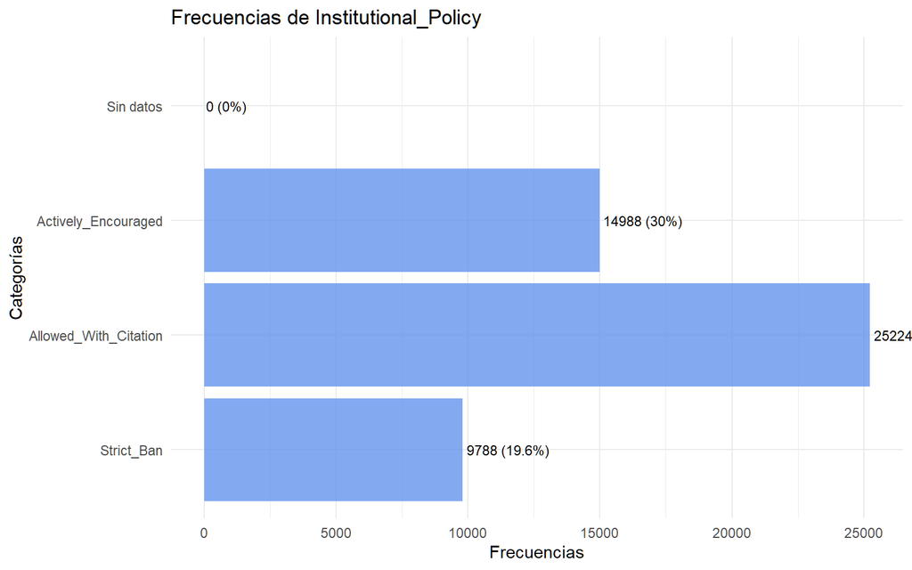

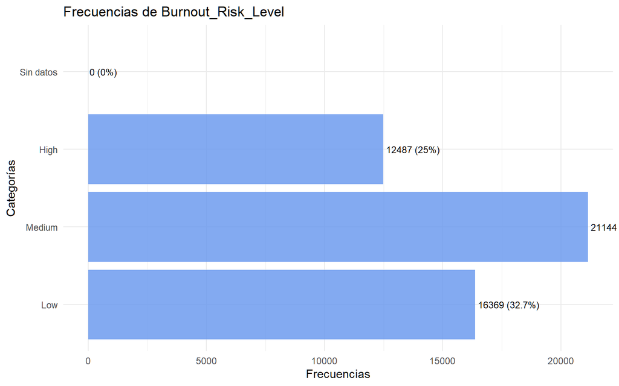

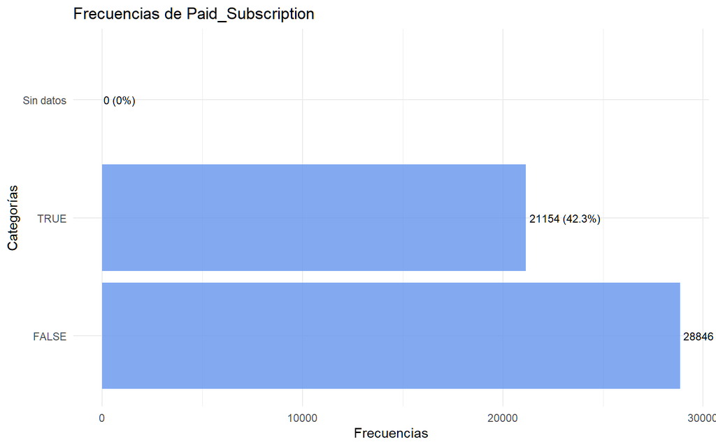

### Observaciones del analisis univariado

La mayor concentración de observaciones corresponde al área STEM (*Science, Technology, Engineering and Mathematics*), con 30.1 % de los datos. Le siguen Business, con 25.1 %; Humanities, con 20 %; Medical, con 13 %; y Arts, con 11.9 %.

### Variables cualitativas vs variables cualitativas

Las tablas de contingencia muestran la frecuencia con la que se cruzan las categorias de dos variables cualitativas. Los mapas de calor representan esas frecuencias mediante intensidad de color, lo que facilita identificar combinaciones mas y menos frecuentes.

Para cada par de variables se aplica una prueba chi-cuadrado de independencia:

- $H_0$: las variables categoricas son independientes.
- $H_1$: existe una asociacion entre las variables categoricas.

El p-valor indica si la diferencia entre frecuencias observadas y esperadas es dificil de explicar solo por azar. La $V$ de Cramer complementa esta decision porque, con una muestra grande, la significancia estadistica debe analizarse junto con la magnitud practica de la asociacion.